# R Notebook

4a. Use ggpairs() to investigate correlations between median_house_value and the predictors (this may take a while to run, don’t worry, make coffee or something).

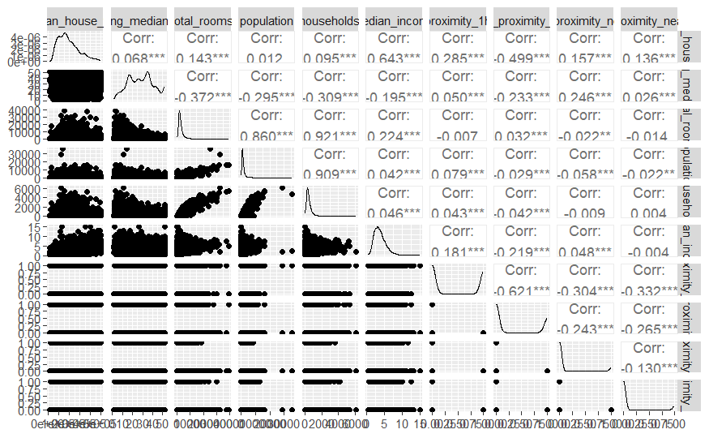

```r
housing_dummy %>% ggpairs(columns = c("median_house_value", "housing_median_age", "total_rooms", "population", "households", "median_income", "ocean_proximity_1h_ocean", "ocean_proximity_inland", "ocean_proximity_near_bay", "ocean_proximity_near_ocean"))
```

```r
# mod1 <- lm(median_house_value ~ total_rooms + population + households + median_income + housing_median_age, housing_prices)
# autoplot(mod1)
```

Strong correlation between median_house_value and median income. There is also a moderate correlation between median_house_value and ocean_proximity_inland. There is also a very strong correlation between household and population, total rooms and households, and also between population and total rooms, but we are not interested in these ones for now.

4b. Perform further ggplot visualisations of any significant correlations you find.

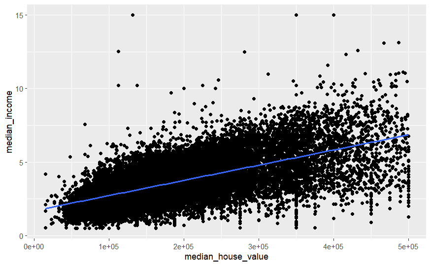

```r
housing_dummy %>%
  ggplot(aes(median_house_value, median_income))+
  geom_point()+
  geom_smooth(method = "lm")
```

```r
# housing_dummy %>%
#   ggplot(aes(median_house_value, ocean_proximity_inland))+
#   geom_col()
```

Shortly we may try a regression model to fit the categorical predictor ocean_proximity. Investigate the level of ocean_proximity predictors. How many dummy variables do you expect to get from it?

```r
housing_prices %>% group_by(ocean_proximity) %>%
  summarise(proximity_type_count = count(ocean_proximity))
```

| ocean_proximity | proximity_type_count |
| --- | --- |
| <1H OCEAN | 8604 |
| INLAND | 6524 |
| ISLAND | 5 |
| NEAR BAY | 2096 |
| NEAR OCEAN | 2446 |

Ocean_proximity has 5 levels which indicates that there could be 4 dummy variables ( the fifth one would be dropped)

6. Start with simple linear regression. Regress median_house_value on median_income and check the regression diagnostics.

```r
model <- lm(formula = median_house_value ~  median_income, data =  housing_dummy)
model
```

```
Call:
lm(formula = median_house_value ~ median_income, data = housing_dummy)

Coefficients:
  (Intercept)  median_income
        45457          39987
```

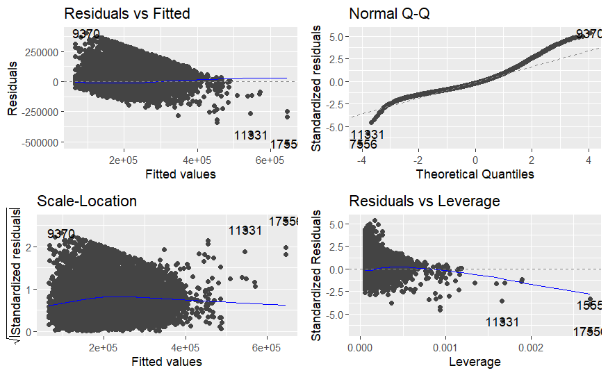

```r
autoplot(model)
```

For each 10,000 USD the median house value goes by 39987 USD.

```r
mod2
```

```
Call:
lm(formula = median_house_value ~ median_income + total_rooms,
    data = housing_prices)

Coefficients:
  (Intercept)  median_income    total_rooms
    4.552e+04      4.000e+04     -4.428e-02
```